# Spruce cone development Biological QA

Nicolas Delhomme

2016-12-05

# 1 Setup

Set the working dir

```r
setwd("/mnt/picea/projects/spruce/onilsson/cone-development/set1")
```

Load libraries

```r
suppressPackageStartupMessages(library(DESeq2))
suppressPackageStartupMessages(library(gplots))
suppressPackageStartupMessages(library(parallel))
suppressPackageStartupMessages(library(pander))
suppressPackageStartupMessages(library(RColorBrewer))
suppressPackageStartupMessages(library(scatterplot3d))
suppressPackageStartupMessages(library(vsn))
```

Source some helper functions

```r
source("~/Git/UPSCb/src/R/plot.multidensity.R")
```

Create a palette

```r
pal <- brewer.pal(8,"Dark2")
```

Register the default plot margin

```r
mar <- par("mar")
```

Read the sample information

```r
samples <- read.csv("~/Git/UPSCb/projects/spruce-cone-development/doc/samples.csv",
                    row.names=1,as.is=TRUE)
```

Read the HTSeq files in a matrix

```r
res <- mclapply(dir("htseq",pattern="*.txt",full.names=TRUE),function(fil){
  read.delim(fil,header=FALSE,stringsAsFactors=FALSE)
},mc.cores=max(mcaffinity()))

names(res) <- sub(".*_P1387","P1387",sub("_sortmerna.*\\.txt","",dir("htseq",pattern="*.txt")))
```

Reorder the sample data.frame according to the way the results were read in and accounting for tech reps

```r
samples <- samples[match(names(res),samples$SciLifeID),,drop=FALSE]
```

Raw Data QC analysis

```r
addInfo <- c("__no_feature","__ambiguous","__too_low_aQual","__not_aligned","__alignment_not_unique")
sel <- match(addInfo,res[[1]][,1])
count.table <- do.call(cbind,lapply(res,"[",3))[-sel,]
colnames(count.table) <- names(res)
rownames(count.table) <- res[[1]][,1][-sel]
dir.create(file.path("analysis","HTSeq"),recursive = TRUE, showWarnings = FALSE)
write.csv(count.table,"analysis/HTSeq/raw-unormalised-data.csv")
```

Extract the HTSeq stat lines

```r
count.stats <- do.call(cbind,lapply(res,"[",2))[sel,]
colnames(count.stats) <- names(res)
rownames(count.stats) <- sub("__","",addInfo)
count.stats <- rbind(count.stats,aligned=colSums(count.table))
count.stats <- count.stats[rowSums(count.stats) > 0,]
```

Convert them into percentages

```r
pander(apply(count.stats,2,function(co){round(co*100/sum(co))}))
```

Table continues below

|  | P1387_101 | P1387_102 | P1387_103 | P1387_104 |
| --- | --- | --- | --- | --- |
| **no_feature** | 20 | 20 | 20 | 19 |
| **alignment_not_unique** | 8 | 8 | 8 | 8 |
| **aligned** | 72 | 72 | 72 | 73 |

Table continues below

|  | P1387_105 | P1387_106 | P1387_107 | P1387_108 |
| --- | --- | --- | --- | --- |
| **no_feature** | 19 | 20 | 21 | 21 |
| **alignment_not_unique** | 8 | 8 | 8 | 8 |
| **aligned** | 73 | 72 | 71 | 71 |

Table continues below

|  | P1387_109 | P1387_110 | P1387_111 | P1387_112 |
| --- | --- | --- | --- | --- |
| **no_feature** | 20 | 20 | 21 | 21 |
| **alignment_not_unique** | 8 | 8 | 8 | 8 |
| **aligned** | 72 | 72 | 71 | 71 |

Table continues below

|  | P1387_113 | P1387_114 | P1387_115 | P1387_116 |
| --- | --- | --- | --- | --- |
| **no_feature** | 20 | 20 | 21 | 20 |
| **alignment_not_unique** | 8 | 8 | 8 | 8 |
| **aligned** | 73 | 72 | 71 | 72 |

Table continues below

|  | P1387_117 | P1387_118 | P1387_119 | P1387_120 |
| --- | --- | --- | --- | --- |
| **no_feature** | 19 | 20 | 19 | 19 |
| **alignment_not_unique** | 8 | 8 | 8 | 8 |
| **aligned** | 73 | 73 | 73 | 73 |

Table continues below

|  | P1387_121 | P1387_122 | P1387_123 | P1387_124 |
| --- | --- | --- | --- | --- |
| **no_feature** | 20 | 21 | 20 | 20 |
| **alignment_not_unique** | 8 | 8 | 8 | 8 |
| **aligned** | 72 | 71 | 72 | 72 |

Table continues below

|  | P1387_125 | P1387_101 | P1387_102 | P1387_103 |
| --- | --- | --- | --- | --- |
| **no_feature** | 19 | 20 | 20 | 20 |
| **alignment_not_unique** | 8 | 8 | 8 | 8 |
| **aligned** | 73 | 72 | 72 | 72 |

Table continues below

|  | P1387_104 | P1387_105 | P1387_106 | P1387_107 |
| --- | --- | --- | --- | --- |
| **no_feature** | 19 | 19 | 20 | 21 |
| **alignment_not_unique** | 8 | 8 | 8 | 8 |
| **aligned** | 73 | 73 | 72 | 71 |

Table continues below

|  | P1387_108 | P1387_109 | P1387_110 | P1387_111 |
| --- | --- | --- | --- | --- |
| **no_feature** | 21 | 20 | 20 | 21 |
| **alignment_not_unique** | 8 | 8 | 8 | 8 |
| **aligned** | 71 | 72 | 72 | 71 |

Table continues below

|  | P1387_112 | P1387_113 | P1387_114 | P1387_115 |
| --- | --- | --- | --- | --- |
| **no_feature** | 21 | 20 | 20 | 21 |
| **alignment_not_unique** | 8 | 8 | 8 | 8 |
| **aligned** | 71 | 73 | 72 | 71 |

Table continues below

|  | P1387_116 | P1387_117 | P1387_118 | P1387_119 |
| --- | --- | --- | --- | --- |
| **no_feature** | 20 | 19 | 20 | 19 |
| **alignment_not_unique** | 8 | 8 | 8 | 8 |
| **aligned** | 72 | 73 | 73 | 73 |

Table continues below

|  | P1387_120 | P1387_121 | P1387_122 | P1387_123 |
| --- | --- | --- | --- | --- |
| **no_feature** | 20 | 20 | 21 | 20 |
| **alignment_not_unique** | 8 | 8 | 8 | 8 |
| **aligned** | 73 | 72 | 71 | 72 |

|  | P1387_124 | P1387_125 |
| --- | --- | --- |
| **no_feature** | 20 | 19 |
| **alignment_not_unique** | 8 | 8 |
| **aligned** | 72 | 73 |

Plot the stats

There are no outliers

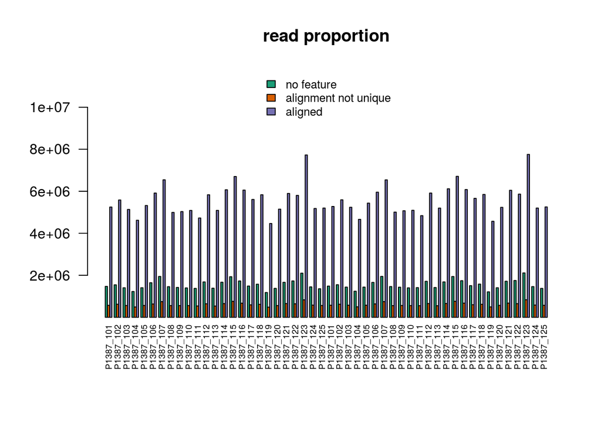

```r
col <- pal[1:nrow(count.stats)]
par(mar=c(7.1,5.1,4.1,2.1))
barplot(as.matrix(count.stats),col=col,beside=TRUE,las=2,main="read proportion",
        ylim=range(count.stats) + c(0,4e+6),cex.names=.6)
legend("top",fill=col,legend=gsub("_"," ",rownames(count.stats)),bty="n",cex=0.8)
```

```r
par(mar=mar)
```

The average percentage of aligned reads is 72%

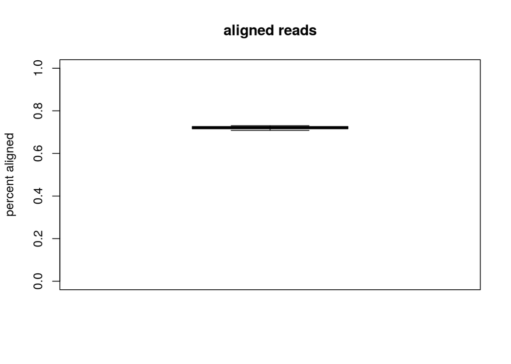

```r
# round(mean(unlist(count.stats["aligned",]/colSums(count.stats))),digits=2)*100
boxplot(unlist(count.stats["aligned",]/colSums(count.stats)),
        main="aligned reads",ylab="percent aligned",ylim=c(0,1))
```

Check how many genes are never expressed

```r
sel <- rowSums(count.table) == 0
sprintf("%s%% percent (%s) of %s genes are not expressed",
        round(sum(sel) * 100/ nrow(count.table),digits=1),
        sum(sel),
        nrow(count.table))
```

```
## [1] "32.4% percent (22921) of 70736 genes are not expressed"
```

Display the per-gene mean expression

i.e. the mean raw count of every gene across samples is calculated and displayed on a log10 scale.

The cumulative coverage is as expected, around 100X

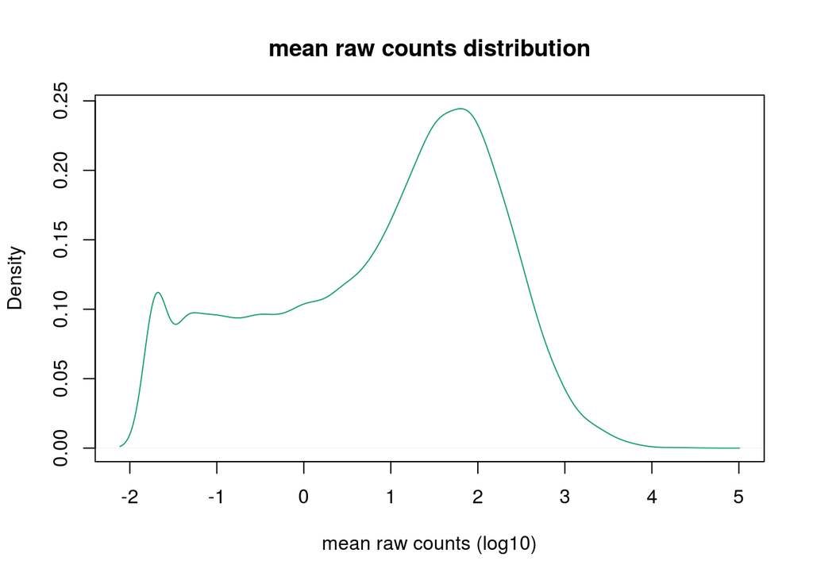

```r
plot(density(log10(rowMeans(count.table))),col=pal[1],
     main="mean raw counts distribution",
     xlab="mean raw counts (log10)")
```

The same is done for the individual samples

The observed distribution is strikingly similar.

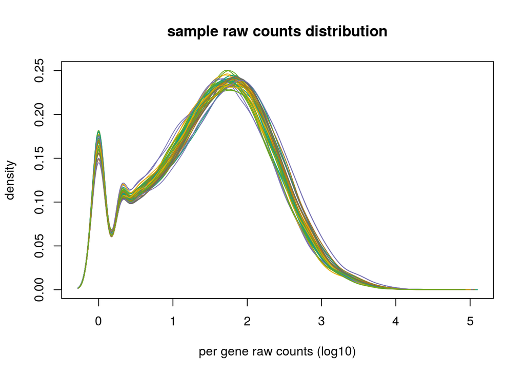

```r
cols <- rep(sample(pal,length(unique(colnames(count.table))),TRUE),2)
plot.multidensity(log10(count.table),
                  col=cols,
                  legend="",
                  legend.col=NA,
                  main="sample raw counts distribution",
                  xlab="per gene raw counts (log10)")
```

# 2 Data normalisation

For visualization, the data is submitted to a variance stabilization transformation using DESeq2. The dispersion is estimated independently of the sample tissue and replicate Create the dds object

```r
conditions <- colnames(count.table)
colnames(count.table) <- make.unique(colnames(count.table))
dds <- DESeqDataSetFromMatrix(
  countData = count.table,
  colData = data.frame(condition=conditions),
  design = ~ condition)
```

Check the size factors (i.e. the sequencing library size effect) There is no big variation, a Variance Stabilizing Transformation can be used (over a Relative Log Transformation)

```r
dds <- estimateSizeFactors(dds)
sizes <- sizeFactors(dds)
names(sizes) <- colnames(count.table)
pander(sizes)
```

Table continues below

| P1387_101 | P1387_102 | P1387_103 | P1387_104 | P1387_105 | P1387_106 |
| --- | --- | --- | --- | --- | --- |
| 1.013 | 1.058 | 0.9822 | 0.8464 | 0.987 | 1.11 |

Table continues below

| P1387_107 | P1387_108 | P1387_109 | P1387_110 | P1387_111 | P1387_112 |
| --- | --- | --- | --- | --- | --- |
| 1.237 | 0.9619 | 0.9433 | 0.9679 | 0.7962 | 1.023 |

Table continues below

| P1387_113 | P1387_114 | P1387_115 | P1387_116 | P1387_117 | P1387_118 |
| --- | --- | --- | --- | --- | --- |
| 0.9177 | 1.089 | 1.217 | 1.156 | 1.003 | 1.064 |

Table continues below

| P1387_119 | P1387_120 | P1387_121 | P1387_122 | P1387_123 | P1387_124 |
| --- | --- | --- | --- | --- | --- |
| 0.8263 | 0.9009 | 1.019 | 1.098 | 1.355 | 0.9246 |

Table continues below

| P1387_125 | P1387_101.1 | P1387_102.1 | P1387_103.1 | P1387_104.1 |
| --- | --- | --- | --- | --- |
| 0.9451 | 1.016 | 1.06 | 1.004 | 0.8546 |

Table continues below

| P1387_105.1 | P1387_106.1 | P1387_107.1 | P1387_108.1 | P1387_109.1 |
| --- | --- | --- | --- | --- |
| 1.01 | 1.12 | 1.234 | 0.9682 | 0.9528 |

Table continues below

| P1387_110.1 | P1387_111.1 | P1387_112.1 | P1387_113.1 | P1387_114.1 |
| --- | --- | --- | --- | --- |
| 0.9699 | 0.818 | 1.035 | 0.9359 | 1.099 |

Table continues below

| P1387_115.1 | P1387_116.1 | P1387_117.1 | P1387_118.1 | P1387_119.1 |
| --- | --- | --- | --- | --- |
| 1.215 | 1.162 | 1.02 | 1.067 | 0.843 |

| P1387_120.1 | P1387_121.1 | P1387_122.1 | P1387_123.1 | P1387_124.1 | P1387_125.1 |
| --- | --- | --- | --- | --- | --- |
| 0.9179 | 1.042 | 1.104 | 1.364 | 0.9318 | 0.9539 |

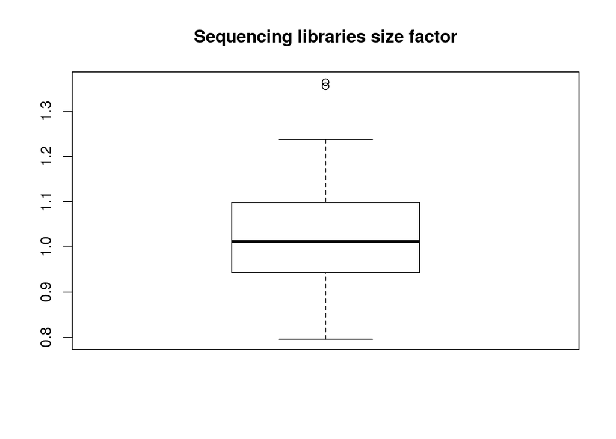

```r
boxplot(sizes, main="Sequencing libraries size factor")
```

Perform the VST

```r
colData(dds)$condition <- factor(colData(dds)$condition,
                                 levels=unique(conditions))
vsd <- varianceStabilizingTransformation(dds, blind=TRUE)
vst <- assay(vsd)
colnames(vst) <- colnames(count.table)
vst <- vst - min(vst)
write.csv(vst,"analysis/HTSeq/library-size-normalized_variance-stabilized_data.csv")
```

Validate the VST

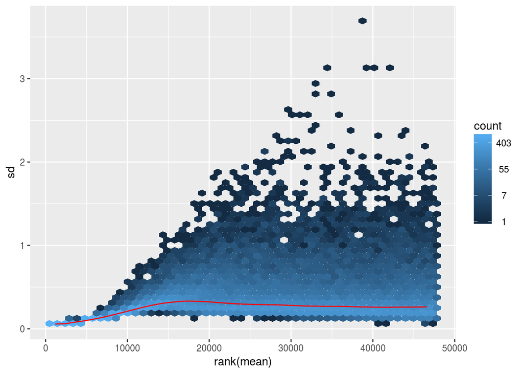

```r
meanSdPlot(vst[rowSums(count.table)>0,])
```

# 3 QC on the normalised data

## 3.1 PCA

First perform a Principal Component Analysis (PCA) of the data to do a quick quality assessment; i.e. replicate should cluster and the first 2-3 dimensions shouldbe explainable by biological means.

```r
pc <- prcomp(t(vst))
percent <- round(summary(pc)$importance[2,]*100)
```

Plot the PCA 3 first dimensions, They are colored by sample (using repeating colors), replicates are dots and triangles

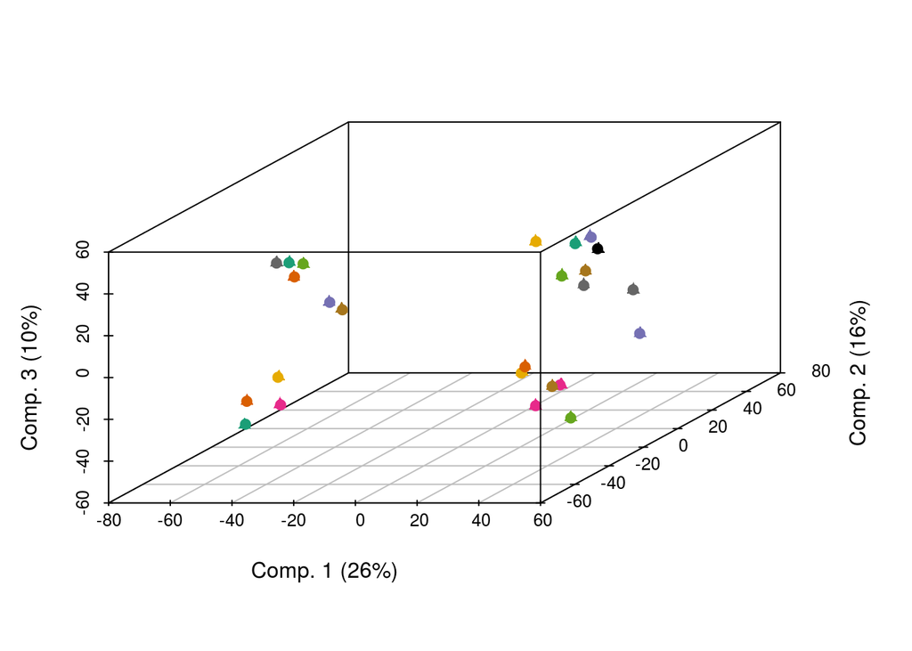

```r
mar=c(5.1,4.1,4.1,2.1)
scatterplot3d(pc$x[,1],
              pc$x[,2],
              pc$x[,3],
              xlab=paste("Comp. 1 (",percent[1],"%)",sep=""),
              ylab=paste("Comp. 2 (",percent[2],"%)",sep=""),
              zlab=paste("Comp. 3 (",percent[3],"%)",sep=""),
              color=rep(c(rep(pal,3),1),2),
              pch=rep(c(17,19),each=25))
```

```r
par(mar=mar)
```

Then the first two dimensions The first dimension separates two set of samples.

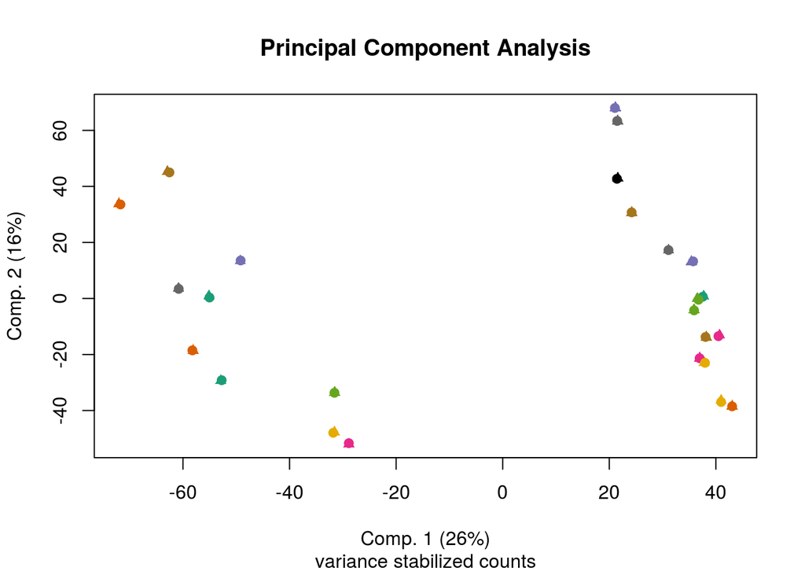

```r
plot(pc$x[,1],
     pc$x[,2],
     xlab=paste("Comp. 1 (",percent[1],"%)",sep=""),
     ylab=paste("Comp. 2 (",percent[2],"%)",sep=""),
     col=rep(c(rep(pal,3),1),2),
     pch=rep(c(17,19),each=25),
     main="Principal Component Analysis",sub="variance stabilized counts")
```

And the 2nd and 3rd dims possibly separate samples on the 3rd dimension also

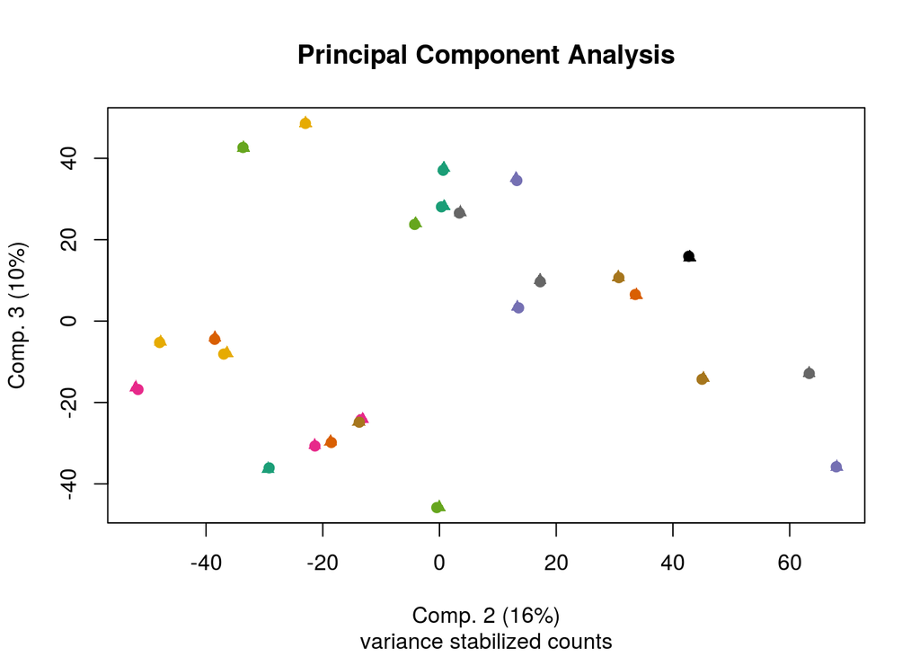

```r
plot(pc$x[,2],
     pc$x[,3],
     xlab=paste("Comp. 2 (",percent[2],"%)",sep=""),
     ylab=paste("Comp. 3 (",percent[3],"%)",sep=""),
     col=rep(c(rep(pal,3),1),2),
     pch=rep(c(17,19),each=25),
     main="Principal Component Analysis",sub="variance stabilized counts")
```

## 3.2 Heatmap

The 1000 most variable genes are selected and plotted as a heatmap

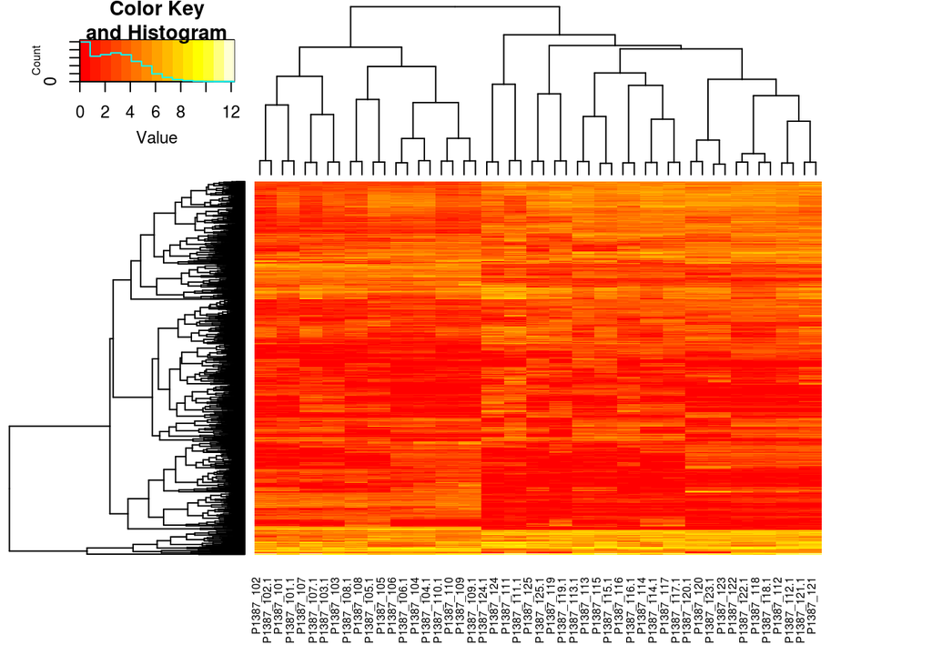

```r
dimnames(vst) <- dimnames(count.table)
sel <- order(apply(vst,1,sd),decreasing=TRUE)[1:1000]
heatmap.2(vst[sel,],labRow = NA,trace = "none",cexCol = 0.6 )
```

# 4 First Conclusion

The raw quality of the data appears very good. The data normalisation gives satisfying results (as far as the VST fit is concerned). The PCA and the heatmap identify 2 to 5 groups, which needs to be re-evaluated once we have the sample information. Finally, it is clear from the analysis that the technical replicates can be combined together, which is what we do next.

```r
count.table <- do.call(cbind,lapply(split.data.frame(t(count.table),samples$SciLifeID),colSums))
write.csv(count.table,"analysis/HTSeq/raw-unormalised_tech-rep-combined_data.csv")
```

# 5 QC using the sample information

Now that we have the sample information about the sex, the sampling date and the replicate number we can redo the QC on these.

```r
samples <- samples[match(colnames(count.table),samples$SciLifeID),]
dds <- DESeqDataSetFromMatrix(
  countData = count.table,
  colData = data.frame(condition=colnames(count.table),
                       sex=samples$Sex,
                       date=samples$Sampling,
                       rep=samples$Sample),
  design = ~ condition)
```

Check the size factors (i.e. the sequencing library size effect) Merging the technical replicates had little effect and as there is still no big variation in the size factor, a Variance Stabilizing Transformation can be used (over a Relative Log Transformation)

```r
dds <- estimateSizeFactors(dds)
sizes <- sizeFactors(dds)
names(sizes) <- colnames(count.table)
pander(sizes)
```

Table continues below

| P1387_101 | P1387_102 | P1387_103 | P1387_104 | P1387_105 | P1387_106 |
| --- | --- | --- | --- | --- | --- |
| 1.011 | 1.054 | 0.9931 | 0.8492 | 0.9975 | 1.111 |

Table continues below

| P1387_107 | P1387_108 | P1387_109 | P1387_110 | P1387_111 | P1387_112 |
| --- | --- | --- | --- | --- | --- |
| 1.231 | 0.9621 | 0.9484 | 0.9663 | 0.8083 | 1.027 |

Table continues below

| P1387_113 | P1387_114 | P1387_115 | P1387_116 | P1387_117 | P1387_118 |
| --- | --- | --- | --- | --- | --- |
| 0.924 | 1.092 | 1.213 | 1.159 | 1.007 | 1.064 |

| P1387_119 | P1387_120 | P1387_121 | P1387_122 | P1387_123 | P1387_124 | P1387_125 |
| --- | --- | --- | --- | --- | --- | --- |
| 0.8343 | 0.9079 | 1.029 | 1.102 | 1.354 | 0.9241 | 0.9427 |

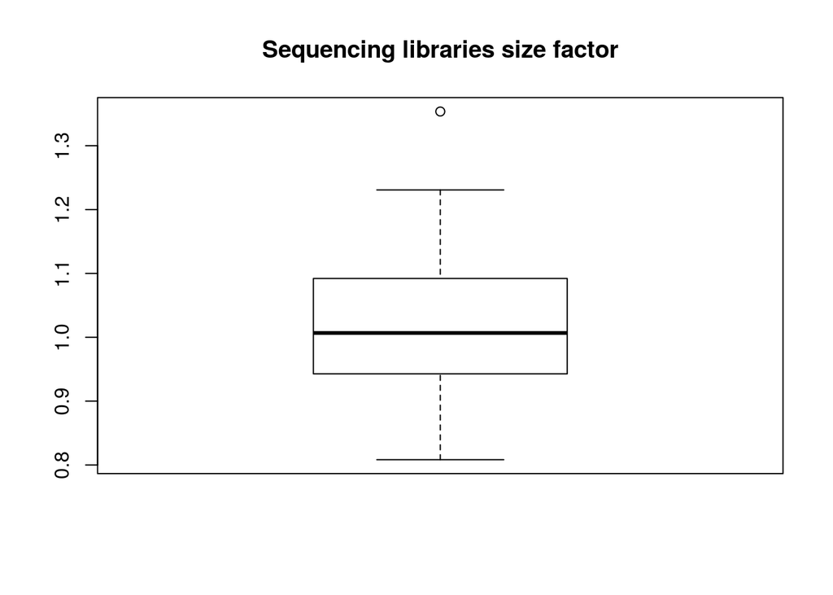

```r
boxplot(sizes, main="Sequencing libraries size factor")
```

Perform the VST

```r
colData(dds)$condition <- factor(colData(dds)$condition,
                                 levels=unique(conditions))
vsd <- varianceStabilizingTransformation(dds, blind=TRUE)
vst <- assay(vsd)
colnames(vst) <- colnames(count.table)
vst <- vst - min(vst)
write.csv(vst,"analysis/HTSeq/library-size-normalized_variance-stabilized_tech-rep-combined_data.csv")
```

Redo the heatmap

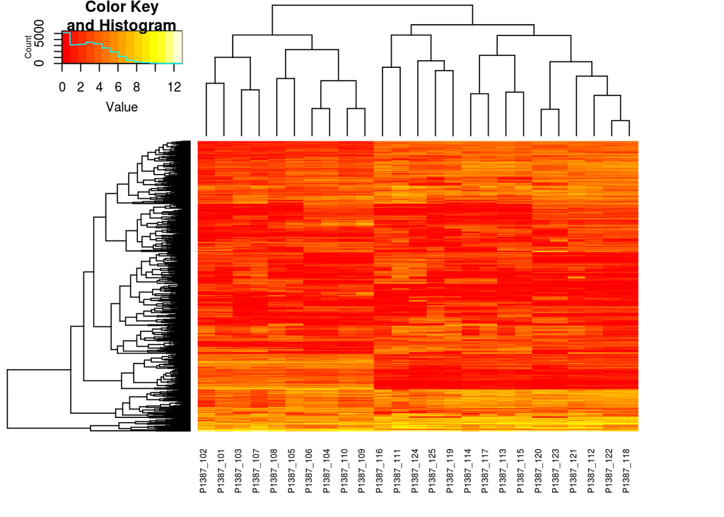

```r
dimnames(vst) <- dimnames(count.table)
sel <- order(apply(vst,1,sd),decreasing=TRUE)[1:1000]
heatmap.2(vst[sel,],labRow = NA,trace = "none",cexCol = 0.6 )
```

labelled by sex

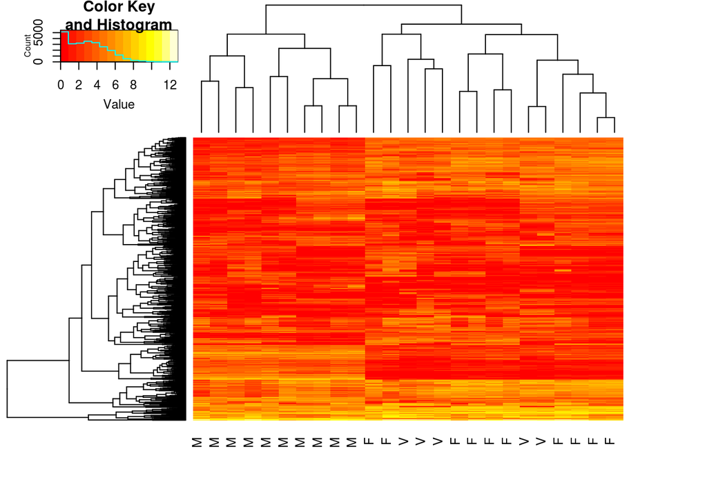

```r
heatmap.2(vst[sel,],labRow = NA,trace = "none", labCol=samples$Sex )
```

labelled by sex and scaled

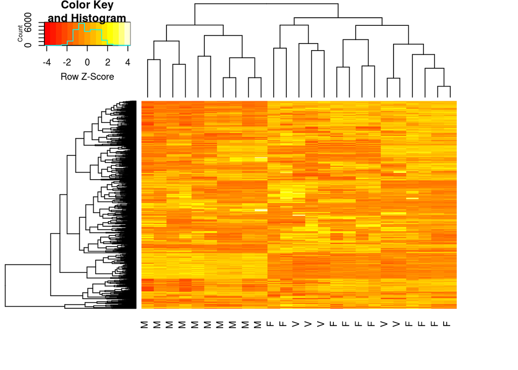

```r
heatmap.2(vst[sel,],labRow = NA,trace = "none", labCol=samples$Sex,
          scale="row")
```

labelled by ID

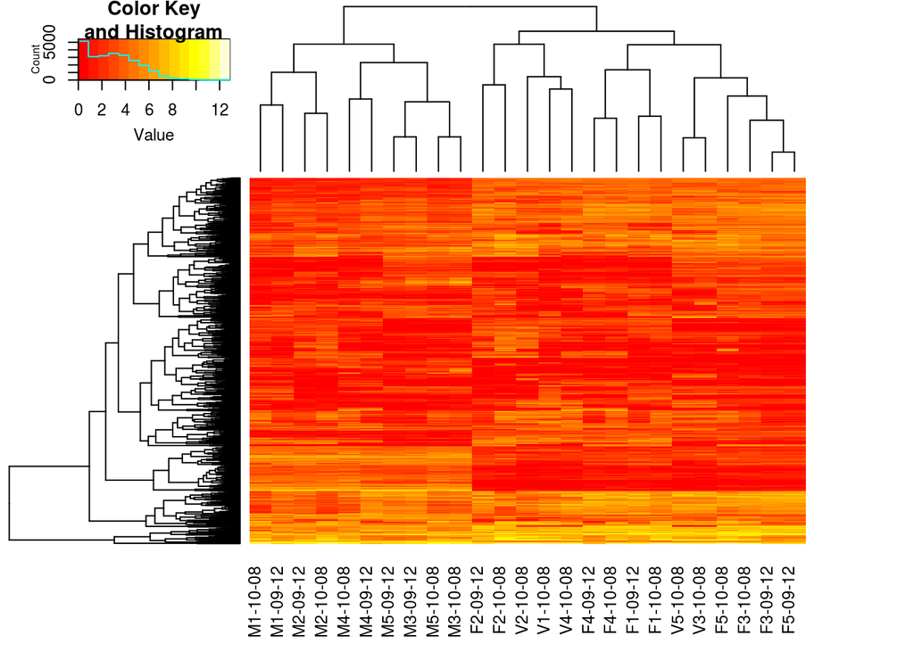

```r
heatmap.2(vst[sel,],labRow = NA,trace = "none", labCol=samples$ID)
```

Finally a PCA

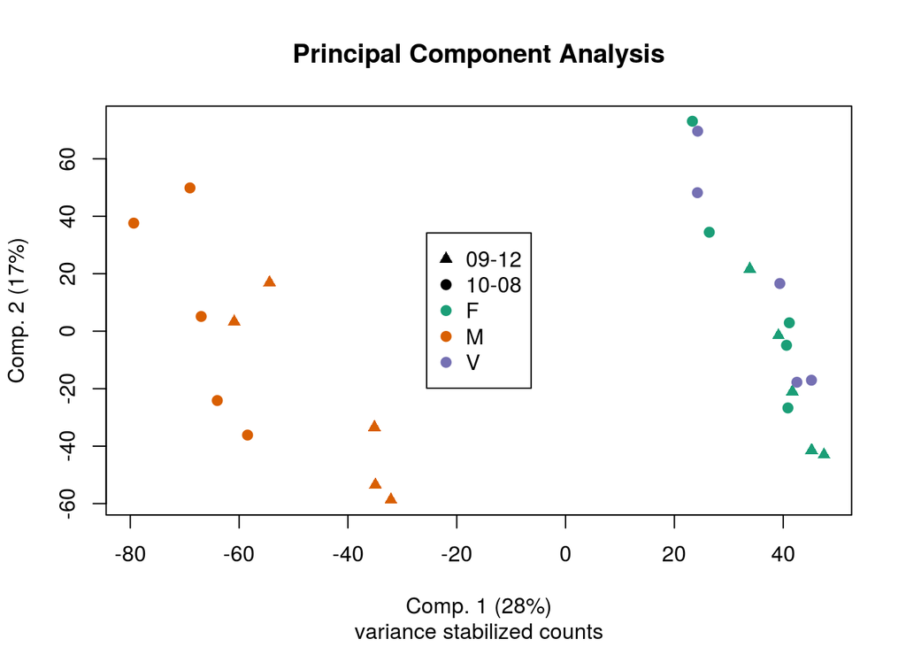

```r
pc <- prcomp(t(vst))
percent <- round(summary(pc)$importance[2,]*100)
plot(pc$x[,1],
     pc$x[,2],
     xlab=paste("Comp. 1 (",percent[1],"%)",sep=""),
     ylab=paste("Comp. 2 (",percent[2],"%)",sep=""),
     col=pal[as.integer(factor(samples$Sex))],
     pch=c(17,19)[as.integer(factor(samples$Sampling))],
     main="Principal Component Analysis",sub="variance stabilized counts")
legend("center",pch=c(17,rep(19,4)),
       col=c(1,1,pal[1:3]),
       legend=c(levels(factor(samples$Sampling)),
                levels(factor(samples$Sex))))
```

PCA looking at the replicate samples, 1st and 2nd dimension

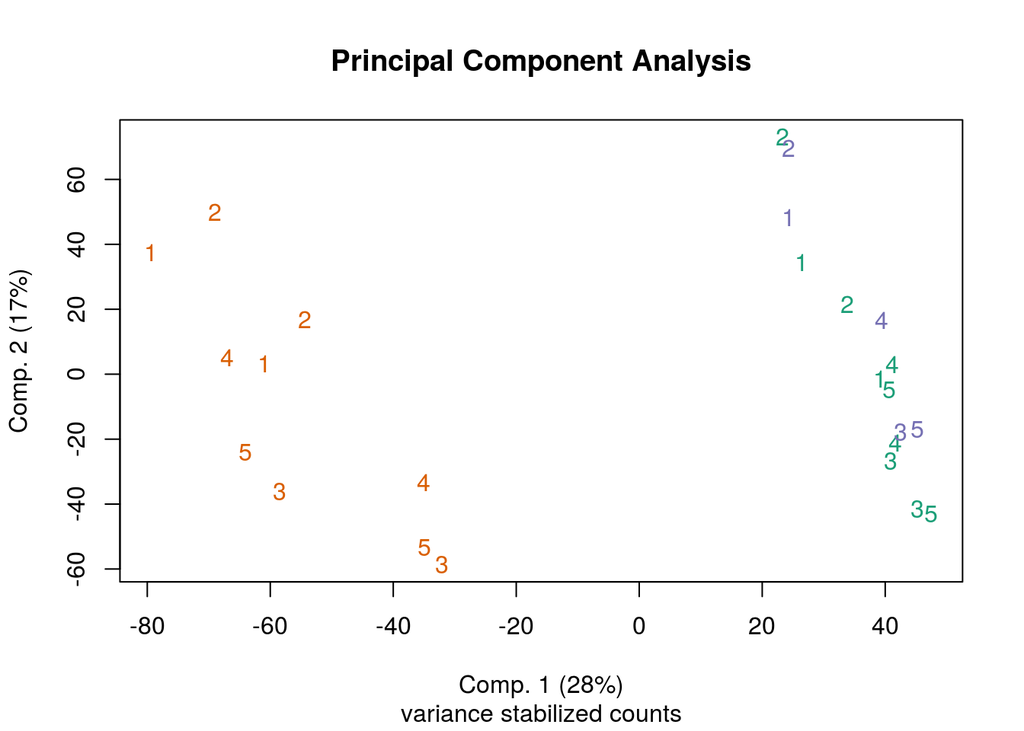

```r
plot(pc$x[,1],
     pc$x[,2],
     xlab=paste("Comp. 1 (",percent[1],"%)",sep=""),
     ylab=paste("Comp. 2 (",percent[2],"%)",sep=""),
     col=pal[as.integer(factor(samples$Sex))],
     pch=as.character(samples$Sample),
     main="Principal Component Analysis",sub="variance stabilized counts")
```

PCA looking at the replicate samples, 2nd and 3rd dimension

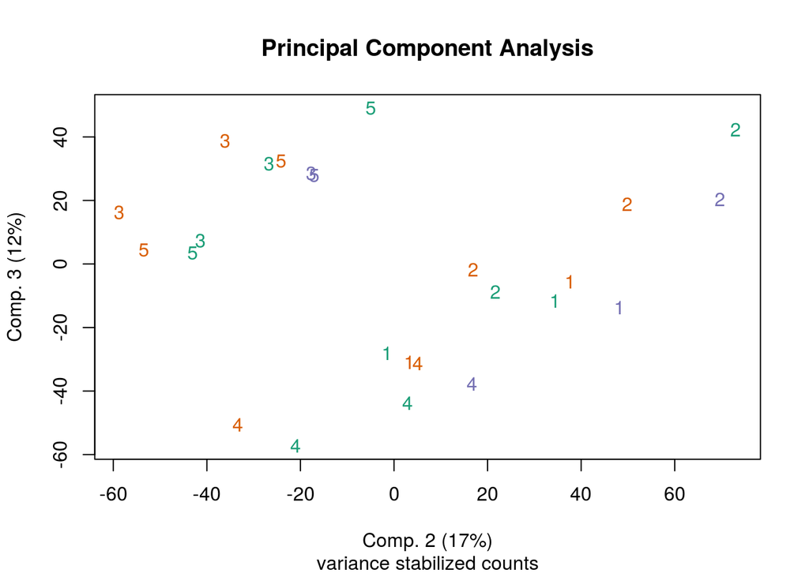

```r
plot(pc$x[,2],
     pc$x[,3],
     xlab=paste("Comp. 2 (",percent[2],"%)",sep=""),
     ylab=paste("Comp. 3 (",percent[3],"%)",sep=""),
     col=pal[as.integer(factor(samples$Sex))],
     pch=as.character(samples$Sample),
     main="Principal Component Analysis",sub="variance stabilized counts")
```

# 6 Second Conclusion

The biological QA of the data looks very promising

As an outlook, here is a list of comparision that could be (or not) done:

1. comparing male vs. female sample is going to reveal the most differentially expressed genes. To increase power, such a design should make sure to block the sampling date effect.
2. as above comparing male vs. vegetative
3. comparing vegetative with female is most likely to unravel only noise or very little DE genes.
4. comparing the sampling date is going to reveal DE genes (there is already a trend visible in the first component for Male samples - and the 2nd and 3rd component, show also in addition to the 1,2,4 vs. 3,5 sample grouping, an effect of time). Obviously, the effect of sex and sample would have to be blocked, which may not be optimal in terms of power.
5. comparing the sample set 1,2,4 and 3,5, as (iv)